# EIT

Fair Predictive Measures for Academy Youth in Sports

Problem Statement

In a country like Uganda, where sports in general has not become a key source of employment yet has created a gap that requires scouting and talent sourcing technology. The current methods used so far revolve around pen and paper as well as observation of players without having to consider their collective talent over a long period of time. The current academies as well have also become expensive for the youth requiring a daily payment of between 1 to 5 euros per session which is not affordable for many of the youth. This then creates a difference between children that are from well off families and poor families leaving out so many from the opportunity of becoming potential sports superstars.

As a nation with the ambition of having players in countries all over Europe and the world, this has become hard as the sports sector is considered for the poor and the educationally challenged thus leaving it in shambles yet results are required. In talent scouting and youth football development, identifying players with the highest potential is both a business and social imperative. However, recent reviews have raised concerns that the current player evaluation pipeline might be unintentionally biased, especially across gender and age especially in a 3rd world country where women are still marginalised as home managers and providers of their men and families.

The ambition of the project is to create an unbiased and fair machine learning program that will widen the net for any potential players in the country and have them participate highly on the national and international stage with in the next 5 to 10 years The goal is to design a fair and interpretable machine learning model that ranks youth football players based on their potential as well as figure out their strengths, weakneses and points of improvement. This model must not only be predictive but also ensure that it does not systematically disadvantage any demographic group. By ensuring fairness, the program will:

• Increase public trust in its scouting processes.

• Attract more diverse applicants.

• Make better long-term investments in talent.

• Reduce on the potential players that are falling through the cracks

• Make the scouting process more fair and affordable for players

• Documentation and clear follow up the progress of the potential players

Data is collected via a structured form filled in CustomTkinter, stored in an Excel sheet. Each record includes player demographics and performance indicators. This is framed as a regression task to predict a "prodigy score" followed by ranking players for selection.

```python
import os
import pandas as pd
import customtkinter as ctk
from tkinter import messagebox

# the information is stored to an excel file. this is preferred because exel files are easy to use and follow by users
EXCEL_FILE = "youth_soccer_players.xlsx"

# the appearance is made to look abit fancy and comfortable for the user whether quakified or not to be able to use it
ctk.set_appearance_mode("System")
ctk.set_default_color_theme("blue")

class SoccerPlayerForm(ctk.CTk):

    def __init__(self):
        super().__init__()

        self.title("Youth Soccer Player Registration")
        self.geometry("450x600")
        self.resizable(False, False)

        # a dictionary is initialised to handle the entries from the user of the program
        self.entries = {}

        # Labels and fields are added to the code. they can be adjusted depending on the requirement of the academy or scouts
        self.fields = [
            ("Name", "text"),
            ("Age", "int"),
            ("Gender", "text"),
            ("Height (cm)", "int"),
            ("Speed (0-100 scale)", "int"),
            ("Technique (0-100 scale)", "int"),
            ("Stamina (0-100 scale)", "int"),
            ("Mental Strength (0-100 scale)", "int"),
            ("Education Grade (0-100 scale)", "int"),
            ("Sports IQ (0-100 scale)", "int"),
            ("Attitude Towards Authority (0-100 scale)", "int"),
            ("Training Drive (0-100 scale)", "int"),
        ]

        self.create_widgets()

    def create_widgets(self):
        ctk.CTkLabel(self, text="Youth Soccer Player Registration Form", font=("Times new roman", 20, "bold")).pack(pady=15)

        # Labels and entry points are generated
        for label, field_type in self.fields:
            frame = ctk.CTkFrame(self)
            frame.pack(padx=20, pady=5, fill="x")

            ctk.CTkLabel(frame, text=label, width=180, anchor="w").pack(side="left", padx=(10, 0))
            entry = ctk.CTkEntry(frame)
            entry.pack(side="right", expand=True, fill="x", padx=(0,10))

            self.entries[label] = (entry, field_type)

        # Submit button is created to push the information to the excel sheet
        submit_btn = ctk.CTkButton(self, text="Submit", command=self.submit_data)
        submit_btn.pack(pady=20)

    def submit_data(self):
        data = {}

        # Data validation and collection is done. this section allows for the data to be taken in as well as prevent the addition of illegitimate information
        for label, (entry, field_type) in self.entries.items():
            value = entry.get().strip()

            if value == "":
                messagebox.showerror("Input Error", f"Please enter {label}.")
                return

            if field_type == "int":
                if not value.isdigit():
                    messagebox.showerror("Input Error", f"{label} must be a number.")
                    return
                value = int(value)

                # This validates the fields with a range scake of 0 to 100, it also prevents addition of figures above 100 and negative values as well
                if "scale" in label.lower() or "grade" in label.lower():
                    if not (0 <= value <= 100):
                        messagebox.showerror("Input Error", f"{label} must be between 0 and 100.")
                        return

                if label == "Age" or label == "Height (cm)":
                    if value <= 0:
                        messagebox.showerror("Input Error", f"{label} must be a positive number.")
                        return

            data[label] = value

        # Appending to the Excel file is done without having to create an entirely new excel sheet or erasing the prior informaion within
        self.save_to_excel(data)

        messagebox.showinfo("Success", "Player information saved successfully!")

        # Clear entries is done to prevent addition of prior information to the newly added youth candidate
        for entry, _ in self.entries.values():
            entry.delete(0, "end")

    def save_to_excel(self, data):
        # if the file doesnt exist, a new one altogether
        if os.path.exists(EXCEL_FILE):
            df = pd.read_excel(EXCEL_FILE)
            new_df = pd.DataFrame([data])
            df = pd.concat([df, new_df], ignore_index=True)
        else:
            df = pd.DataFrame([data])

        df.to_excel(EXCEL_FILE, index=False)


if __name__ == "__main__":
    app = SoccerPlayerForm()
    app.mainloop()
```

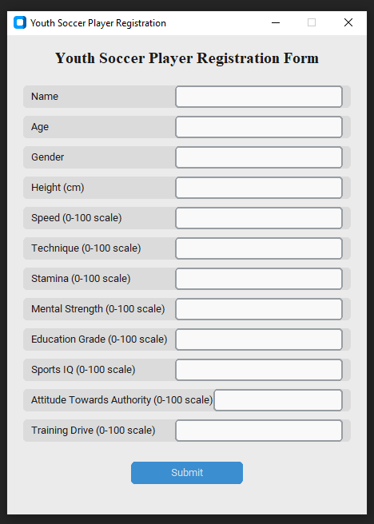

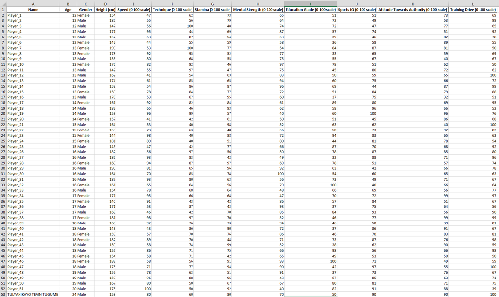

Ethical Concerns

Football has historically been male-dominated, and young female, short and small players are slipping through the cracks of many scouts and academies who would have been world class in the long run. Age bias also arises when coaches prioritize older players in a group for physical maturity. On top of that, there is concern of players having to sacrifice their educational prospects for a time in the sports life, which becomes problem when the sports dream comes to an end they are hardly qualified to do anything afterwards. Training a model without fairness checks might perpetuate these biases.

• Equal opportunity is core to fair sport.

• Bias may lead to missed potential in underrepresented groups.

• It violates principles of transparency and inclusion.

Fair machine learning mitigations are thus essential in this use case.

Approaches to Fairness

The following fairness-aware machine learning methods were considered:

1. Pre-processing: Adjusting data before modeling using techniques like re-weighing or relabeling. These are simple but can distort data realism.
2. In-processing: Applying fairness constraints during training (e.g., Fairlearn's GridSearch using Demographic Parity or Equalized Odds).
3. Post-processing: Altering outputs to balance group outcomes. This may affect interpretability.

In-processing via Fairlearn's GridSearch with Demographic Parity was chosen, as:

• It balances performance and fairness.

• It does not distort input data.

• It integrates well with our RandomForestRegressor base model.

Applying the Fair Model

The dataset was prepared by combining weighted features like speed, technique, stamina, and training drive to generate a raw prodigy score. We then:

• Defined sensitive features: Gender, and intersectionally with Age_Group.

• Split data for training/testing.

• Binarized labels using a top-25% threshold.

• Applied Fairlearn's GridSearch to learn fair predictions.

• Normalized outputs and ranked players.

Fairness metrics were evaluated:

• Selection rate by group using MetricFrame.

• Displayed bias summaries live in the UI.

The UI allows real-time weight adjustment and visual fairness inspection.

How the code works

This Python script creates a CustomTkinter graphical interface that loads youth soccer player data from an Excel file, ranks them based on various performance metrics, and applies fair machine learning to ensure the ranking is unbiased—especially across gender and age group.

It uses:

• CustomTkinter for the UI,

• pandas for data manipulation,

• sklearn for machine learning (Random Forest),

• fairlearn for fairness-aware modeling (Demographic Parity)

```python
import customtkinter as ctk
import pandas as pd
import numpy as np
from tkinter import messagebox
from sklearn.ensemble import RandomForestRegressor
from sklearn.model_selection import train_test_split
from fairlearn.reductions import GridSearch, DemographicParity
from fairlearn.metrics import MetricFrame, selection_rate
```

Key Components

Initialization (**init**)

• Sets up the window title and dimensions.

• Loads data from youth_soccer_players.xlsx.

• If the file doesn’t exist, an error popup is shown.

• Defines feature weights for computing potential score (e.g., Speed, Technique).

• Prepares the UI and computes the initial ranking.

```python
ctk.set_appearance_mode("System")
ctk.set_default_color_theme("blue")

EXCEL_FILE = "youth_soccer_players.xlsx"

class FairRankingApp(ctk.CTk):
    def __init__(self):
        super().__init__()
        self.title("Fair Soccer Player Ranking with Fairlearn Model")
        self.geometry("950x750")

        try:
            self.df = pd.read_excel(EXCEL_FILE)
        except FileNotFoundError:
            messagebox.showerror("File Error", f"Could not find {EXCEL_FILE}. Please place the file in this folder.")
            self.destroy()
            return

        self.weights = {
            "Speed (0-100 scale)": 0.20,
            "Technique (0-100 scale)": 0.25,
            "Height (cm)": 0,
            "Stamina (0-100 scale)": 0.15,
            "Mental Strength (0-100 scale)": 0.15,
            "Education Grade (0-100 scale)": 0.05,
            "Sports IQ (0-100 scale)": 0.10,
            "Attitude Towards Authority (0-100 scale)": 0.05,
            "Training Drive (0-100 scale)": 0.05,
        }

        self.feature_cols = list(self.weights.keys())

        self.create_widgets()
        self.prepare_data()
        self.update_model_and_ranking()
```

User Interface (create_widgets)

Creates UI elements:

• Header label.

• A set of sliders for each performance metric to adjust their importance (weight).

• A button to retrain the model and update rankings based on current weights.

• A Textbox to display the ranked players.

• A label at the bottom to display fairness metrics (e.g., gender balance in selections).

```python
def create_widgets(self):
        header = ctk.CTkLabel(self, text="Adjust Weights & See Fair Player Ranking", font=("Arial", 18, "bold"))
        header.pack(pady=10)

        sliders_frame = ctk.CTkFrame(self)
        sliders_frame.pack(pady=10, fill="x", padx=20)

        self.sliders = {}
        for i, (key, val) in enumerate(self.weights.items()):
            label = ctk.CTkLabel(sliders_frame, text=f"{key} Weight:", width=250, anchor="w")
            label.grid(row=i, column=0, padx=10, pady=5, sticky="w")
            slider = ctk.CTkSlider(sliders_frame, from_=0, to=1, number_of_steps=100, command=self.slider_changed)
            slider.set(val)
            slider.grid(row=i, column=1, padx=10, pady=5, sticky="ew")
            self.sliders[key] = slider
        sliders_frame.grid_columnconfigure(1, weight=1)

        self.train_button = ctk.CTkButton(self, text="Train Fair Model & Update Ranking", command=self.update_model_and_ranking)
        self.train_button.pack(pady=10)

        self.textbox = ctk.CTkTextbox(self, width=900, height=400)
        self.textbox.pack(pady=10, padx=20)

        self.bias_label = ctk.CTkLabel(self, text="", font=("Arial", 12), justify="left")
        self.bias_label.pack(pady=10)

    def slider_changed(self, value):
        total = sum(slider.get() for slider in self.sliders.values())
        if total == 0:
            return
        for key, slider in self.sliders.items():
            self.weights[key] = slider.get() / total
```

Data Preparation (prepare_data)

• Computes a Raw Potential Score by applying the weights to each performance metric:

• Saves the updated data to self.df.

```python
def prepare_data(self):
        df = self.df.copy()

        bins = [0, 12, 15, 18, 100]
        labels = ["<=12", "13-15", "16-18", "19+"]
        df["Age_Group"] = pd.cut(df["Age"], bins=bins, labels=labels, right=False)

        def compute_raw_score(row):
            s = 0
            for feat, w in self.weights.items():
                s += row[feat] * w
            return s

        df["Raw_Potential_Score"] = df.apply(compute_raw_score, axis=1)
        self.df = df
```

Model Training & Ranking (update_model_and_ranking)

a. Prepare Inputs

• Splits the data into X (features), y (target score), and A (sensitive attribute = Gender).

• Splits into train/test sets.

b. Binarize Labels

• Converts the top 25% of players (based on score) into binary labels (1 = elite).

c. Fair Model Training

• Uses RandomForestRegressor with Fairlearn's GridSearch to train a fair model under Demographic Parity:

o Ensures both genders have equal selection rate probability.

d. Predictions

• Predicts the prodigy score for all players.

• Normalizes these predictions between 0–100 to get a fair prodigy chance score.

e. Ranking Display

• Sorts players by their Prodigy_Chance_ score.

• Renders a ranked list with:

o Rank, Name, Gender, Age, and Prodigy Chance (%) in the textbox UI.

```python
def update_model_and_ranking(self):
        self.prepare_data()

        df = self.df.copy()

        X = df[self.feature_cols]
        y = df["Raw_Potential_Score"]
        A = df["Gender"]

        X_train, X_test, y_train, y_test, A_train, A_test = train_test_split(
            X, y, A, test_size=0.3, random_state=42)

        threshold = np.percentile(y_train, 75)
        y_train_bin = (y_train > threshold).astype(int)
        y_test_bin = (y_test > threshold).astype(int)

        base_estimator = RandomForestRegressor(random_state=42)
        mitigator = GridSearch(
            estimator=base_estimator,
            constraints=DemographicParity(),
            grid_size=20,
        )
        mitigator.fit(X_train, y_train_bin, sensitive_features=A_train)

        fair_preds = mitigator.predict(X)

        min_p = fair_preds.min()
        max_p = fair_preds.max()
        prodigy_chance = 100 * (fair_preds - min_p) / (max_p - min_p)
        df["Prodigy_Chance_"] = prodigy_chance

        df_sorted = df.sort_values("Prodigy_Chance_", ascending=False)

        lines = [f"{'Rank':<5} {'Name':<20} {'Gender':<8} {'Age':<4} {'Prodigy Chance (%)':>18}"]
        lines.append("-" * 65)
        for i, row in enumerate(df_sorted.itertuples(), 1):
            lines.append(f"{i:<5} {row.Name[:18]:<20} {row.Gender:<8} {row.Age:<4} {row.Prodigy_Chance_:>17.2f}%")

        self.textbox.delete("0.0", "end")
        self.textbox.insert("0.0", "\n".join(lines))

        mf = MetricFrame(
            metrics={"selection_rate": selection_rate},
            y_true=(y > threshold).astype(int),
            y_pred=(fair_preds > threshold),
            sensitive_features=A,
        )
        bias_text = "Fairness Metric (Selection Rate) by Gender:\n"
        for g, val in mf.by_group.items():
            if hasattr(val, 'iloc'):
                val = val.iloc[0]
            bias_text += f"  {g}: {val:.3f}\n"

        mf_intersection = MetricFrame(
            metrics={"selection_rate": selection_rate},
            y_true=(y > threshold).astype(int),
            y_pred=(fair_preds > threshold),
            sensitive_features=pd.DataFrame({"Gender": df["Gender"], "Age_Group": df["Age_Group"]}),
        )
        bias_text += "\nSelection Rate by Gender + Age Group:\n"
        for key, val in mf_intersection.by_group.items():
            if hasattr(val, 'iloc'):
                val = val.iloc[0]
            if isinstance(key, tuple):
                key_str = " & ".join(str(k) for k in key)
            else:
                key_str = str(key)
            bias_text += f"  {key_str}: {val:.3f}\n"

        self.bias_label.configure(text=bias_text)


if __name__ == "__main__":
    app = FairRankingApp()
    app.mainloop()
```

[figure not shown]

In this demo, you can see the sliders which can be adjusted by any given coach looking to take in a particular player with the qualities they appreciate. It allows the person to actually have a clear perrspective of the strengths and weaknesses of the players they are taking in based on information collected through thorough research and analysis of the individual without any bias, prejudice or discrimination along the lines of ethnicity, gender or background

Fairness Metrics (Displayed Below Ranking)

Uses fairlearn.metrics.MetricFrame to calculate:

• Selection rate by Gender

• Selection rate by Gender + Age_Group (intersectional fairness)

This shows whether the model treats groups equally in terms of elite selection rate.

Final Discussion

Strengths:

• Live fairness-aware ranking.

• Intuitive and interactive user interface.

• Simple and direct to use by the scouting and coaching staff

Limitations:

• Demographic Parity may not be optimal if groups differ in true label distribution.

• Requires enough group diversity to be effective.

• Training size may affect model calibration.

Business Implications:

• Promotes equity in talent selection.

• Avoids reputational risk from bias claims.

• Sets a new benchmark in ethical AI for sports.

Recommendations:

• Encourage diverse data collection (more players, varied backgrounds).

• Periodically audit the system.

• Explore Equalized Odds or Adversarial De-biasing for long-term use.

• Consult domain experts (coaches, scouts) when interpreting fairness results.

• Develop an android application that is both portable and efficient